# Tema 6 Inferencia estadística

## INFERENCIA ESTADÍSTICA

La inferencia estadística es el conjunto de técnicas estadísticas que nos permiten llegar a conclusiones sobre una población a partir de los datos de una muestra de dicha población. La estadística por tanto parte de los datos para extraer unas conclusiones, es un método deductivo. Para dar soporte teórico a la estadística existe el cálculo de probabilidades, que lo que proporciona es un método inductivo, es decir desde una regla es capaz de llegar a la misma conclusión. Tanto para la estadística como para la probabilidad, existen dos corrientes:

Frecuentista: Se basa en la repetición continuada de los hechos. Cuanto más se repita un experimento, la probabilidad de que ocurra un suceso será más regular y su frecuencia relativa se acercará mucho a la probabilidad del suceso.

**USAREMOS ESTE MÉTODO CUANDO NO SEPAMOS ANTES LAS PROBABILIDADES DE CADA SUCESO, POR EJEMPLO QUE UNA MONEDA ESTÉ TRUCADA Y NO SEPAMOS CÓMO, SÓLO POREMOS SABER SU PARCIALIDAD REPITIENDO, POR ELLO SE LLAMA CONOCIMIENTO A POSTERIORI**

La interpretación clásica, mayoritaria por lo menos hasta ahora, define la probabilidad en términos de experimentación. Si repites un experimento un número infinito de veces y compruebas que en 350 de cada 1.000 ocasiones se ha producido un determinado resultado, un frecuentista diría que la probabilidad de ese resultado es del 35%. Basándose en esta definición, un frecuentista afirma que es posible asociar a cada evento una probabilidad de obtener un valor VERDADERO del mismo.

La aproximación clásica se basa por lo tanto en estudiar la probabilidad real de las cosas, tratando de determinar hasta qué punto una medición realizada sobre un conjunto de experimentos se aproxima a la probabilidad real que subyace. Es por ello que un frecuentista definiría probabilidad como una expresión matemática que predice en qué medida es verosímil que ciertos eventos ocurran basándose en el patrón observado hasta este momento.

El enfoque frecuentista considera que los datos son aleatorios debido a la naturaleza del proceso que los genera y que cada vez que repitamos el experimento obtendremos un resultado diferente. De la misma forma cree que la hipótesis será cierta o falsa para el proceso estudiado pero que debido a la naturaleza aleatoria de los datos nuestro análisis puede señalarla como falsa cuando es cierta (falso negativo) o verdadera cuando es falsa (falso positivo). Por ello el enfoque frecuentista nos proporcionará, además de una respuesta a la pregunta de si la hipótesis es cierta o falsa, una probabilidad denominada p-valor. Este número es un indicador cuantas veces tendríamos que repetir la toma de datos y el análisis estadístico para obtener el resultado opuesto. Nótese que, al ser los datos aleatorios, siempre puede ser que acabe usando un conjunto que me apunte en la dirección contraria a la que realmente se comporta la población total.

Bayesiana: Hace un anális basado en la certeza que se tiene de que un hecho ocurrirá. Las observaciones se usan para actualizar o inferir la posibilidad de una hipótesis. Es una estrategia complementaria a la frecuentista, ya que con cada iteración añadiríamos un conocimiento obtenido en esa iteración para enriquecer el cálculo de la probabilidad.

**USAREMOS ESTE MÉTODO CUANDO SEPAMOS A PRIORI LAS PROBABILIDADES DE CADA SUCESO, POR EJEMPLO AL LANZAR UNA MONEDA PERFECTA, POR ESO SE LLAMA CONOCIMIENTO A PRIORI,SABEMOS ANTES QUE LA PROBABILIDAD ES 50%**

Por el contrario, la interpretación bayesiana se basa en un conocimiento limitado de las cosas. Afirma que sólo asocias una probabilidad a un evento porque hay incertidumbre sobre el mismo, es decir, porque no conoces todos los hechos. En realidad, un evento dado, o bien ocurrirá (probabilidad=100%) o bien no ocurrirá (probabilidad=0%). Cualquier otra cosa es una aproximación que hacemos del problema a partir de nuestro conocimiento incompleto del mismo. El enfoque bayesiano se basa por lo tanto en la idea de refinar predicciones a partir de nuevas evidencias. Un bayesiano definiría probabilidad como la expresión matemática que mide el nivel de conocimiento que tenemos para hacer una predicción. Por lo tanto, para un bayesiano, estríctamente hablando es incorrecto decir predigo que hay un 30% de probabilidades de que ocurra el evento P, sino que debería decir basándome en el conocimiento actual que tengo, tengo un 30% de certeza de que P ocurrirá.

Los frecuentistas piensan en los parámetros como unos valores fijos pero desconocidos. La estimación se basa en la elección de aquellos valores de los parámetros que maximizan la probabilidad de observar los datos.

Por su parte, los bayesianos interpretan los parámetros como variables aleatorias cuya distribución de probabilidad es estudiada en base al Teorema de Bayes. La idea es simple, un bayesiano ha de tener una distribución subjetiva de los parámetros antes de ver los datos (a priori) que modificará en función de los datos que haya observado para obtener una distribución a posteriori que resumirá todo el conocimiento del investigador sobre los parámetros de interés dados los datos y sus creencias a priori.

Los bayesianos le dan la vuelta al enfoque frecuentista. Para ellos los datos son fijos, no aleatorios porque ¿no se han obtenido ya? ¿Qué tienen de aleatorios los valores anotados en esas tablas que hemos ido generando? En cambio la hipótesis es para ellos aleatoria y puede ser o no verdad. Los bayesianos no determinan si la hipótesis es cierta o falsa, únicamente calculan la probabilidad (en sentido bayesiano) de que sea cierta o falsa.

Finalmente, sabemos que hay muchos resultados frecuentistas que pueden obtenerse desde una perspectiva bayesiana aunque la filosofía subyacente sea diferente. Mínimos cuadrados ordinarios (MCO) es el ejemplo más sencillo. Dicho estimador frecuentista coincide exactamente con la media de la distribución bayesiana bajo unas creencias concretas en el marco del modelo lineal normal. Existen en la literatura muchos otros ejemplos.

El objetivo de las técnicas de inferencia estadística es contrastar la hipótesis nula (Ho) y la hipótesis alternativa (H1), y en este sentido se pueden cometer dos tipos de error:

```
Error tipo I o alfa --> Rechazar la hipótesis nula siendo esta verdadera.
Error tipo II o beta --> Rechazar la hipótesis alternativa siendo esta cierta. La probabilidad complementaria del tipo II se llama poder de contraste (p-value) y es 1-beta.Este valor está totalmente impactado por el tamaño de la muestra, ya que el intervalo de confianza se va reduciendo cuanto mayor es el espacio muestral, por tanto más probable es rechazar Ho de manera efectiva.
```

La base de la inferencia estadistica es la probabilidad. Esta, asigna un número entre 0 y 1 que significa la posibilidad de que sea cierto. La probabilidad es el modelo de inferencia que se usa habitualmente para hacer estimaciones sobre fenómenos aparentemente aleatorios.

Teniendo en cuenta la conexión entre ambos enfoques en la práctica y la posibilidad de obtener los mismos resultados bajo ambos enfoques, los bayesianos argumentan que su interpretación del problema es siempre más intuitiva y natural. Recordemos que un bayesiano proporcionaría conclusiones del tipo: hay un 95% de probabilidad de que el parámetro esté entre 0,3 y 0,8, sin embargo, un frecuentista afirmaría: si generáramos 100 muestras aleatorias del mismo tamaño y repitiéramos la estimación 100 veces, en 95 de ellas el parámetro estimado estaría entre 0,3 y 0,8.

Los contrastes de hipótesis parecen por tanto más naturales en el marco bayesiano. Para un bayesiano convencido, un p-valor o un t-ratio es una herejía, ya que lo único que necesitamos para contrastar hipótesis es tener la distribución a posteriori de los parámetros. Salvo en contadas excepciones, un frecuentista basa su contraste de hipótesis en el análisis asintótico, es decir, en calcular p-valores de la distribución asintótica del estimador (no del parámetro verdadero, que es un valor fijo). Esta distribución, mayoritariamente normal gracias a numerosos teoremas centrales del límite, es la que el estimador tendría si el investigador tuviera muchos más datos de los que realmente tiene. ¿es ésta una buena forma de hacer inferencia en general? Por el contrario, el bayesiano se basa en la distribución de los parámetros dados sus datos, que puede en principio tener cualquier forma no gaussiana.

Al admitir información adicional, los métodos bayesianos reconocen que cada problema es distinto y promueven que el procedimiento de análisis se adapte al problema en cuestión, y no al revés; como consecuencia, tienden a ser más flexibles. Sin embargo, para poder hacer esto posible, la implementación de las técnicas bayesianas usualmente requiere de un esfuerzo computacional muy alto. La mayor parte de este esfuerzo se concentra en el cálculo de ciertas características de la distribución final del parámetro de interés. Por ejemplo, hay que integrar para pasar de una distribución conjunta a una colección de distribuciones marginales que sean útiles para hacer inferencias sobre los parámetros de interés. En la gran mayoría de los problemas las integrales requeridas no pueden resolverse analíticamente, por lo que es necesario contar con métodos numéricos eficientes que permitan calcular o aproximar integrales en varias dimensiones.

El enfoque bayesiano no sustituye el estudio de las frecuencias, lo enriquece con experiencias anteriores ya que puede ir refinando hacia atrás los resultados obtenidos en cada iteración. Un ejemplo extremo es que si en los últimos 4.500 millones de años en Cuenca ha salido el sol por el levante, suponemos que la probabilidad de que mañana vaya a volver a salir el sol es más alta con un estudio bayesiano de lo que sería con un análisis de estadística clásica, que no da ningún peso a la historia pasada. Pero cuando un médico pronostica le quedan unos seis meses de vida, querríamos creer que el galeno nos está facilitando esta información no sólo en base a un análisis de las frecuencias para esta dolencia, sino que además incorpora su experiencia de otros diagnósticos similares, y en especial nuestro propio historial clínico. Las conclusiones son afectadas por la premisa, pero si ésta es bien formulada, más que un defecto sería una ventaja

Afortunadamente, durante la segunda mitad del siglo XX se comenzaron a desarrollar técnicas numéricas flexibles y eficientes basadas en métodos de simulación estocástica. Esto, aunado al desarrollo de la tecnología que ha dado lugar a una mayor capacidad de procesamiento y de almacenamiento de los equipos de cómputo gracias a la virtualización, el Cloud Computing y el Big Data, está provocando un auge de los métodos bayesianos.

Probablidad es la cantidad de población que resume una aleatoriedad.Dos herramientas muy útiles para el cálculo de probabilidad son la distribución de probabilidad y la función de distribución

Esto es, ante la pregunta de si una hipótesis es correcta, los frecuentistas responden un sí o un no pero apostillan con qué frecuencia obtendrías el resultado opuesto mientras que los bayesianos no responden directamente y se limitan a indicar cómo de seguros están de uno u otro resultado.

Haremos usos de ambos métodos dependiendo de lo que necesitemos calcular. Usaremos por ejemplos métodos frecuentistas para el cálculo del error muestral y comparación entre muestras. Mientras que usaremos métodos bayesianos para el cálculo de especificidad y sensibilidad.

## TEORÍA DE LA PROBABILIDAD

Dado un experimento aleatorio (por ejemplo lanzar un dado) su medida de probabilidad es la cantidad de dicha población que mide la aleatoriedad.

Está muy bien explicado en el siguiente artículo, del que he tomado algunas notas:

https://blogs.20minutos.es/mati-una-profesora-muy-particular/tag/probabilidad-condicionada/

Específicamente, la probabilidad toma un posible valor del experimento dónde:

- Assigna un número entre 0 y 1.
- La probabilidad de que algo ocurra seguro es 1.
- La probabilidad de la unión de dos conjuntos de posibles resultados que no tienen nada en común (son mutuamente excluyentes, por ejemplo que salga un 2 o un 4 en un lanzamiento) es la suma de sus respectivas probabilidades.

Para asignar una probabilidad a un suceso, echamos mano de la regla de Laplace

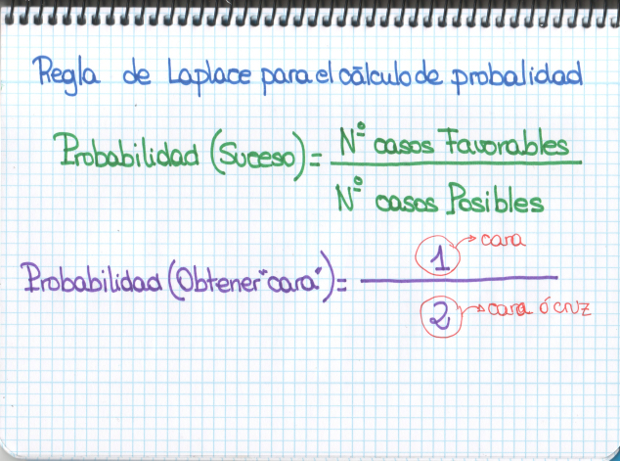

laplace

En un caso más ámplio, como en el lanzamiento de dados

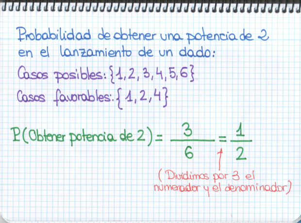

laplace

El matemático ruso **Kolgomorov** formalizó estas reglas de probabilidad.

- La probabilidad de nada ocurra es 0
- La probailidad de que sí ocurra es 1
- La probabilidad de un hecho es 1 menos la probabilidad del hecho opuesto

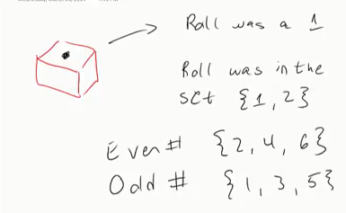

kolgomorov

- La probabilidad de que sucedan al menos uno de dos (o más) cosas que no pueden ocurrir simultáneamente es la suma de sus probabilidades (UNIÓN DE CONJUNTOS)

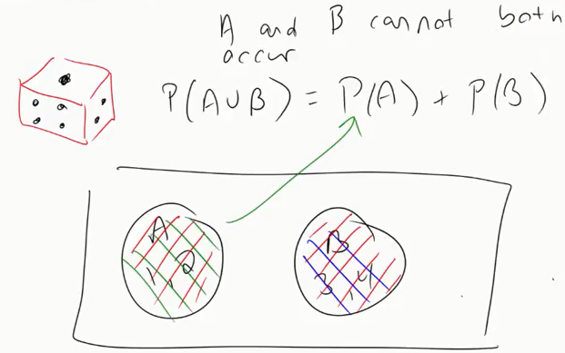

kolgomorov

- Si un evento A implica la ocurrencia de un evento B, entonces la probabilidad de que ocurra A es menor que la probabilidad de que ocurra B (INCLUSIÓN DE CONJUNTOS)

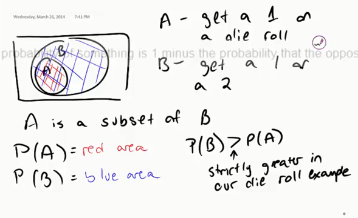

qownnotes-media-GBLpWb

- Para cualquiera de dos eventos (o más) la probabilidad de que ocurran es la suma de sus probabilidades menos su intersección. (INTERSECCIÓN DE CONJUNTOS)

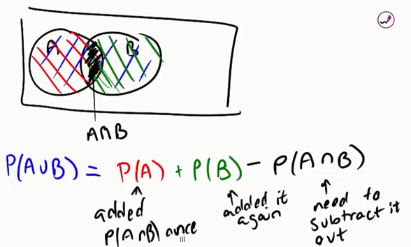

qownnotes-media-waZsrq

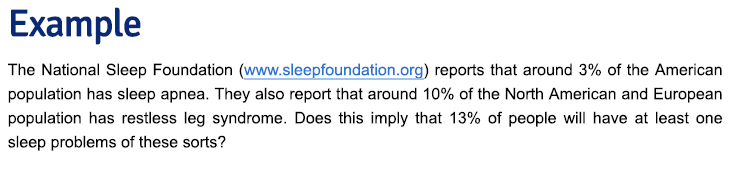

kolgomorov

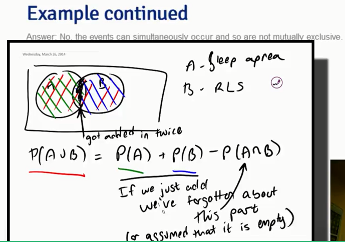

qownnotes-media-mTAmEg

$$\begin{eqnarray*}
A_1 & = & \{\mbox{Person has sleep apnea}\} \\
A_2 & = & \{\mbox{Person has RLS}\}
\end{eqnarray*}$$
$$\begin{eqnarray*}
P(A_1 \cup A_2 ) & = & P(A_1) + P(A_2) - P(A_1 \cap A_2) \\
& = & 0.13 - \mbox{Probability of having both}
\end{eqnarray*}$$

Una **Variable aleatoria** es el resultado numérico de un experimento. Las variables aleatorias tienen dos naturalezas, o discreta o contínua.

Un ejemplo de variable discreta es todo lo que sea contar un número de cosas(por ejemplo machos y hembras, o cualquier otra variable categórica), un ejemplo de continua es la medida de tu peso durante un mes.

Supongamos que deseamos conocer algún parámetro poblacional, por ejemplo la edad media de una población. En el contexto de la estadística clásica (frecuentista), podríamos extraer al azar múltiples y diferentes muestras representativas de forma sucesiva y determinar el estimador más apropiado en cada una de esas muestras. Para este caso, el estimador más apropiado para la media poblacional es la media muestral. Cada una de las medias de estas muestras tomarían un determinado valor diferente para cada muestra (o lo que es lo mismo, el estimador es tratado como una variable en sí mismo).En estadística, un estimador es un estadístico (esto es, una función de la muestra) usado para estimar un parámetro desconocido de la población.

Suponiendo la normalidad de la variable edad, los valores que irían tomando estas medias muestrales se distribuirían según una curva de Gauss (algunos de estos valores se darían con mayor frecuencia y otros con menor frecuencia). El área bajo dicha curva de distribución de frecuencias del estimador es la probabilidad total, es decir, la unidad.

## DISTRIBUCIÓN DE PROBABILIDAD

### Función de probabilidad (función de masa de probabilidad, PMF en ingles DISCRETOS)

Función que determina la probabilidad de cada evento posible, cuando los posibles valores son DISCRETOS: ejemplo:

- valor p(1) -> 0.3
- valor p(4) ->0.6
- valor p(7)->0.1

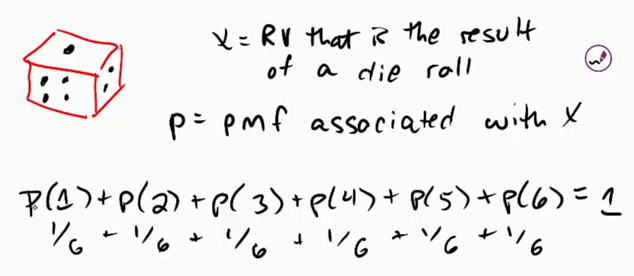

PMF valores discretos

Las distribuciones de probabilidad en base a su PMF más comunes son Bernoulli (valor p o p-1 muy útil para la prevalencia de una enfermedad), binomial (bernuilli repetido n veces) o poisson(contar el número de veces que se da un evento en el tiempo)

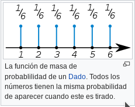

PMF valores discretos

### Función de densidad (PDF en ingles CONTINUO)

Función que determina la probabilidad de cada evento posible, cuando los posibles valores son CONTINUOS, por ejemplo probabilidad asociada a tiempo de espera en urgencias.

Ejemplo la proporción de llamadas que pueden ser atendidas en un día para dar citas en consultas externas sigue la siguiente curva:

$$f(x) = \left\{\begin{array}{ll}
2 x & \mbox{ for } 1 > x > 0 \\
0 & \mbox{ otherwise}
\end{array} \right.$$

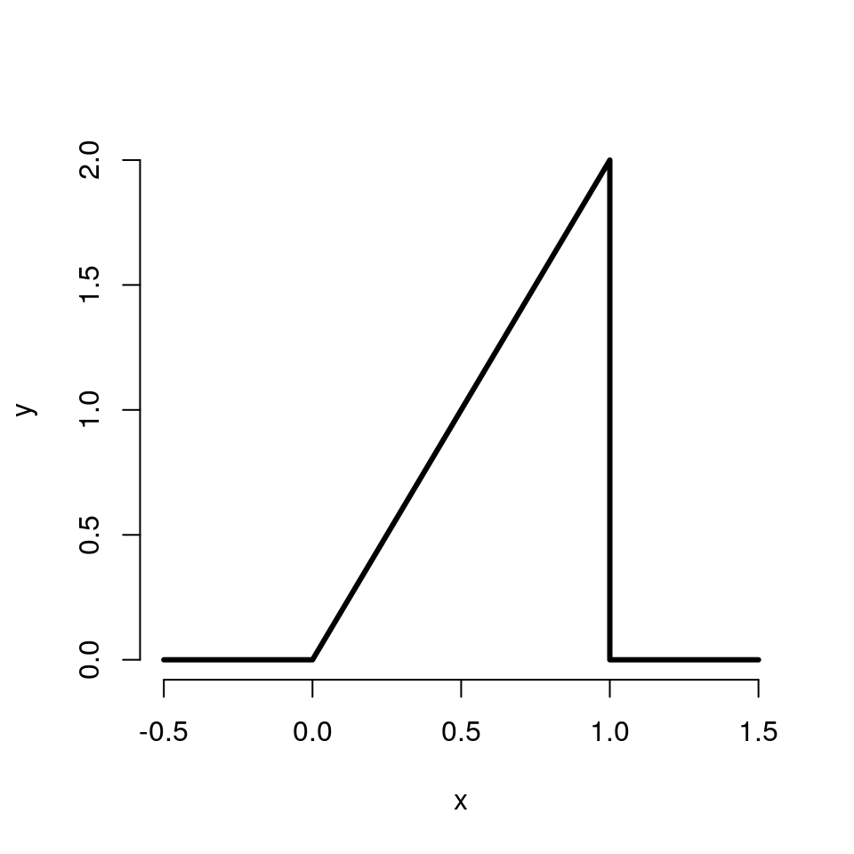

```r
x <- c(-0.5, 0, 1, 1, 1.5); y <- c( 0, 0, 2, 0, 0)
plot(x, y, lwd = 3, frame = FALSE, type = "l")
```

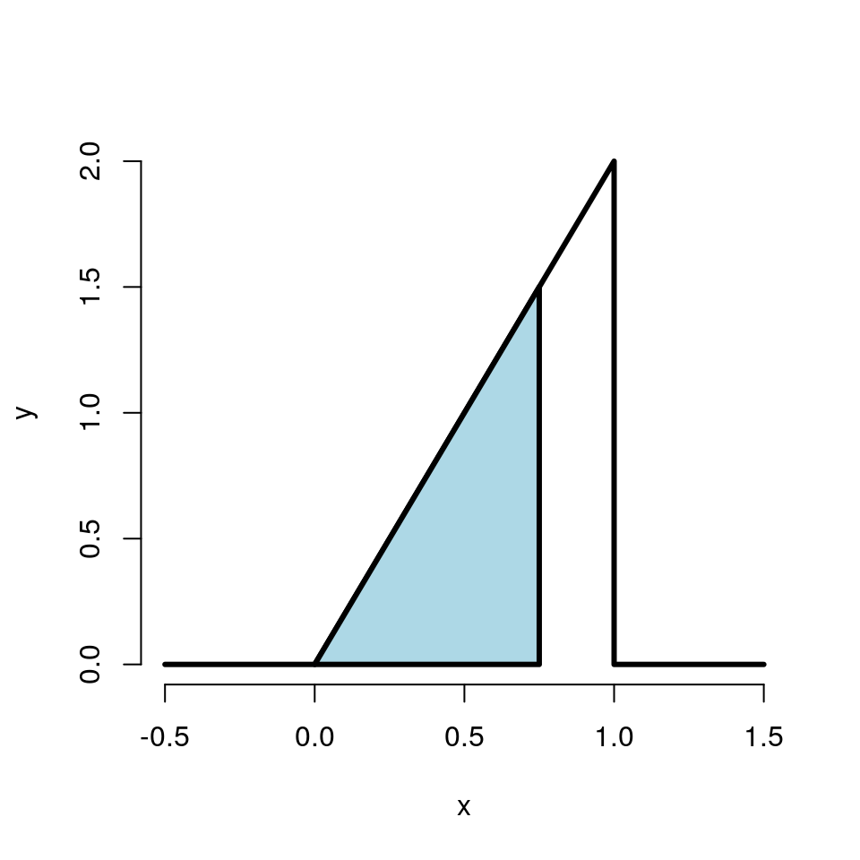

Esta operación es muy sencilla ya que se puede calcular con trigonometría o através de la función beta, que es justo para distribuciones de probabiidad trianangular

```r
1.5 * .75 / 2
```

```
## [1] 0.5625
```

```r
pbeta(.75, 2, 1)
```

```
## [1] 0.5625
```

Ya que calculamos el área bajo la curva, si elegimos un valor concreto su pdf nos dara 0,ya que el area de una recta es 0.

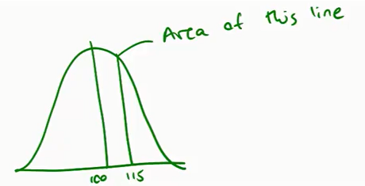

Area bajo curva de una recta es 0

Las distribuciones de probabilidad en base a su PDF más comunes son Normal (la normal estandar es la que tiene e(x) = 0 y d(x) = 1)o de Gaus o exponencial (el tiempo entre dos eventos)

Los histogramas, pueden representar esta función de densidad en base a probabilidades o bien en base a número de ocurrencias de cada evento. EN nuestro caso, esto es fundamental ya que las probabilidades que vamos a manejar en el mundo de la la sanidad están todas basadas en la ocurrencia de un suceso, no en un cálculo a priori de sus probabilidades.

A la hora de representarlo, el histograma será mucho menos fiable para conocer su PDF ya que depende en gran medida del número de separaciones que hagamos, es más fiable utilizar diagrama de densidad kernel

http://www.statmethods.net/graphs/density.html

### FUNCION DE DISTRIBUCION(CDF en ingles)

Es la probabilidad igual o menor asociada a un valor (probabilidad acumulada). Nos va a resultar muy útil para hacer el cálculo de la media en variables contínuas, ya que para su cálculo necesitamos este valor asociado a la variable.

$$F(x) = P(X \leq x)$$
Por otro lado la función de supervivencia será la que represente la probabilidad mayor a un valor

$$S(x) = P(X > x)$$

Como se puede ver por tanto $S(x) = 1 - F(x)$

En variables contnuas, la PDF es la derivada de la CDF, como se puede ver en el ejemplo:

$$F(x) = P(X \leq x) = \frac{1}{2} Base \times Height = \frac{1}{2} (x) \times (2 x) = x^2$$
La función de supervivencia por tanto será:
$$S(x) = 1 - x^2$$

Esto puede ser calculado facilmente con la función pbeta, por ejmplo la probabilidad de atender el 40,50 y 60% de las llamadas

```r
pbeta(c(0.4, 0.5, 0.6), 2, 1)
```

```
## [1] 0.16 0.25 0.36
```

Las probabilidades de la CDF se puede expresar también en Cuantiles y Percentiles

CUANTILES cuando tienes cuantil 0.95 significa que el 95% de la población está por debajo de tí, es decir se centra en el valor de la probabilidad menor o igual en lugar del resultado.

El cuantil alfa es el valor de la X que te da un valor concreto de cuantil. Ejemplo Cuantil alfa de 0.98 es X=6 PERCENTIL es el cuantil expresado en porcentaje

La media es el percentil 50%

En este ejemplo, queremos saber el cuantil 0.5 es decir la probabilidad de atender el 50% de las llamadas $0.5 = F(x) = x^2$

```r
sqrt(0.5)
```

```
## [1] 0.7071068
```

Podemos hacer uso téambin de nuevo de pbeta:

```r
qbeta(0.5, 2, 1)
```

```
## [1] 0.7071068
```

Hasta aqui hemos hablado en todo momento de medias sin tener en cuenta los datos, esto es así porque estamos calculando la media de la POBLACIÓN, un modelo de probabilidad conecta los datos con la población a través de asunciones. Por tanto la media de la que hemos estado hablando es el estimando, mientras que la media de la máuestra será el estimador.

## PROBABILIDAD CONDICIONAL

La probabilidad de que un suceso pase sabiendo que ha pasado otro. En este caso, el hecho de conocer de antemano un hecho relaccionado (DEPENDIENTE) nos hace modificar la probabilidad de que ocurra el hecho en el que estamos interesados.

Esta es la base de la **aproximación Bayesiana**, ya que aportamos conocimiento a nuestra predicción y modificamos su probabilidad respecto a ese conocimiento.

- Pongamos un hecho B = de manera que $P(B) > 0$
- **La probabilidad condicionada** de otro evento A, sabiendo previamente que ha ocurrido B es definido como la probabilidad de que los DOS ocurran dividido por la probabilidad de que B occurra
  $$P(A\:|\:B) = \frac{P(A \:\cap\: B)}{P(B)}$$
- En el caso de A y B sean *independientes*, entonces
  $$P(A\:|\:B) = \frac{P(A)P(B)}{P(B)} = P(A)$$

Un ejemplo de probabilidad condicionada, es qué probabilidades tengo de sacar un 1 si sé que ha salido impar.

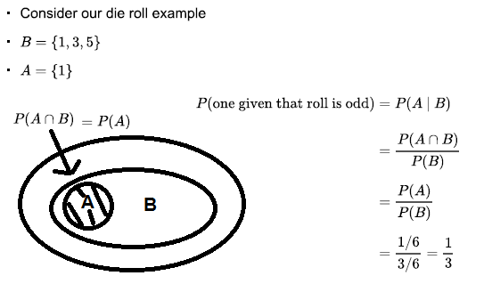

qownnotes-media-jvqfcq

El típico ejemplo de sucesos dependientes es el de sacar bolas de una bolsa. Si tenemos 5 bolas rojas y 3 bolas verdes en una bolsa, ¿cuál es la probabilidad de meter la mano y sin mirar sacar una bola roja?

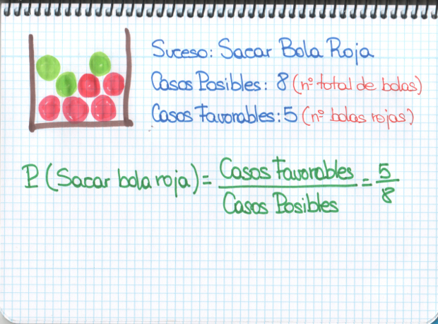

sucesosDependientes

La dejamos fuera ¿Y la probabilidad de que la segunda sea roja?Esto implica que el resultado del segundo experimento depende del primero. Lo que queremos conocer es la probabilidad de que en la segunda extracción (ya hay una bola fuera) saquemos una bola roja. A esa probabilidad que queremos calcular la llamaremos P(2ªR). Para calcular P(2ªR) vamos a necesitar calcular otras probabilidades antes. Por ejemplo, la probabilidad de que la 2ª bola sea roja condicionada al hecho de que la primera que salió fuese roja, lo llamamos P(2ªR | 1ªR)

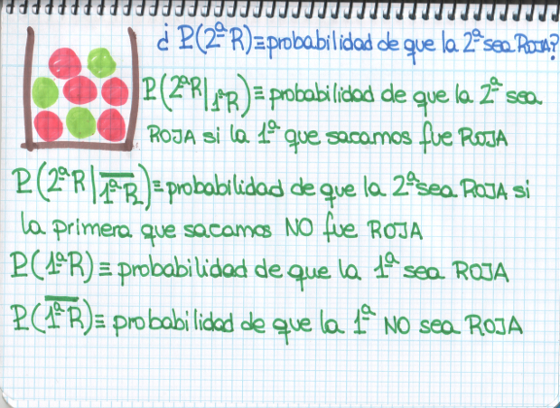

sucesosDependientes

Una vez tenemos todas las partes implicadas, será sumar las probabilidades de que la segunda haya sido roja condicionada a que la primera sea roja y que la segunda sea roja condicionando a que la primera no sea roja

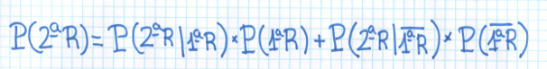

Este caso es muy sencillo y podemos haer los cálculos símplemente contando

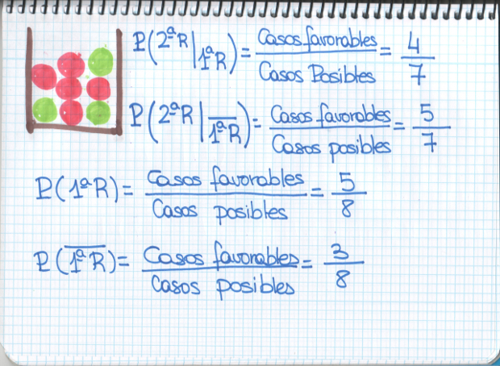

sucesosDependientes

Ya sólo queda hacer la suma:

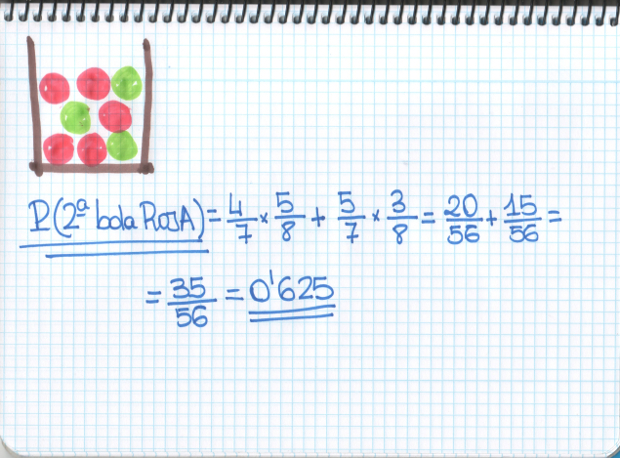

sucesosDependientes

**Teorema de Bayes** Es el uso más famoso de la probabilidad condicional. Calcula la probabilidad de A condicionado a B desde la probabilidad de que pase B condicionado a A. Este teorema nos da la posibilidad de conocer las probabilidades condicionadas cruzadas de ambos eventos entre sí.

$$P(B\:|\:A) = \frac{P(A\:|\:B)P(B)}{P(A\:|\:B)P(B)+P(A\:|\:B^c)P(B^c)}$$
donde $B^c$ = corresponde a la probabilidad de que no suceda el evento $B$, $P(B^c) = 1 - P(B)$

Es muy útil para calcular la efectividad de test diagnósticos ya que nos relacciona la efectividad del resultado de un test (Hecho A) con que realmente se tenga la enfermedad (Hecho B). Ejemplo: + y - son los resultados de diagnóstico de un test médico, y D que el sujeto tenga la enfermedad.

Probabilidad de que el test sea positivo = $P(+)$ Probabilidad de que el test sea negativo = $P(-)$ Probabilidad de que se tenga la enfermedad = $P(D)$ Probabilidad de que no se tenga la enfermedad = $P(D^c)$

**SENSIBILIDAD** es la probabilidad de que el test sea positivo sabiendo que individuo tiene la enfermedad (Nos indica cómo ha funcionado). Es desable que sea alto, ya que indicará que nuestro test es fiable cuando da positivo.

Sensibilidad = $P(+\:|\:D)$

**ESPECIFIDAD** es la probabilidad de que el test sea negativo sabiendo que el individuo no tiene la enfermedad (Nos indica cómo ha funcionado). También es desable que sea alto, ya que indicará que nuestro test es fiable cuando da negativo.

Especificidad = $P(-\:|\:D^c)$

**Prevalencia aparente** Es la probabilidad de tener sepsis observada = $P(D)$

**Prevalencia real** es practicamente imposible de determinar pero se puede aproximar desde la prevalencia aparente con el estimador Rogan-Gladen

**Valor predictivo positivo** Probabilidad de que tenga la enfermedad sabiendo que el test es positivo (Nos indica cómo va a funcionar, tiene en cuenta prevalencia) = $P(D\:|\:+)$

**Valor predictivo negativo** Probabilidad de no tener la enfermedad sabiendo que el test es negativo (Nos indica cómo va a funcionar, tiene en cuenta prevalencia) = $P(D^c\:|\:-)$

**Razón de verosimilitud diagnóstica** -> Existen con el fin de dimensionar el beneficio clínico de un test de manera independiente a la prevalencia, ya que esta puede variar.

**Odds ratio** Asociación entre exposición y resultado. Ejemplo de razón de oportunidad de indice de cancer de pulmón en fumador es 2. Esto significa que fumadores tienen 2 veces más probab. de tener cancer. = $p/(1-p)$

Diferencia entre probability y odds:

Probabilidad 0.80 Odds 0.80/1-0.80 = 4 –> Odds de 4 a 1

[output not shown]

| Test | Séptico | No séptico | TOTAL |
| --- | --- | --- | --- |
| Pos | 8503 | 2758 | 11261 |
| Neg | 37 | 355024 | 355061 |
| TOTAL | 8540 | 357782 | 366322 |

Prevalencia aparente= (8503+37)/(8503+37+2758+355024)=0.023

Prevalencia real = (Prev.apa+Espec-1)/(Sensib.+Espec-1) = (0.023+0.992-1)/(0.995+0.992-1)= 0.01519757

Proporción falso positivo = 2758/11261 = 0.24

Proporción falson negativo = 37/355061 = 0.0001

Sensibilidad = 8503/(8503+37) = 0.995

Especificidad = 355024/(2758+355024) = 0.992

VPP = 8503/(8503+2758) = 0.75

DLR+ = (sensibilidad/1-especificidad) = 124

DLR- = (1-sensibilidad/especificidad) = 0,005

Odds ratio (razón de oportunidades) = (8503/2758)/(37/355024) = 29582.43

Ratio o razón –> Indice obtenido al dividir dos cantidades. Ninguno de los elementos del numerador estón incluidos en el denominador

```
Ejemplo Ratio alerta post = 8503/2758 = 3.08 por cada 3 alertas salta 1 que no es
```

Proporción -> El numerador está incluido en el denominador

```
    Proporcion alerta post =  8503/(8503+2758) = 0.75
```

Tasa -> Magnitud de cambio de un parámetro por unidad de cambio de otro que incluye una medida adiconal de tiempo en el denominador

```
Tasa de pacientes septicos en 2018: 8540/366322 = 0.023 es una tasa
de 23 pacientes septicos por cada 1000 urgencias.
```

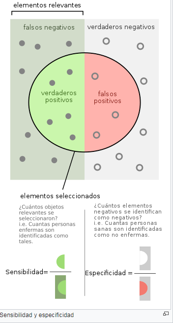

qownnotes-media-tBAWRb

**POSITIVE PREDICTIVE VALUE** es la probabilidad de tener la enfermedad sabiedo que el test es positivo.

**NEGATIVE PREDICTIVE VALUE** es la probabilidad de no tener la enfermedad sabiendo que el test es negativo.

En la ausencia de un test, se llama **PREVALENCIA** a la probabilidad de tener esa enfermedad.

[figure not shown]

qownnotes-media-dOUpkP

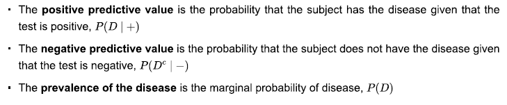

qownnotes-media-tLsDNl

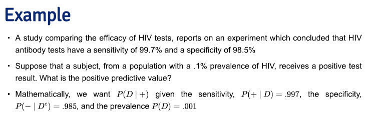

qownnotes-media-pPYGcB

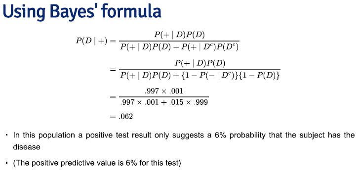

qownnotes-media-RUIsxz

**DLR+** es cada cuantos test positivos acertados se da un test negativo err?neo en este caso 998/15 = 66, cada 66 test positivos acertados se da 1 negativo err?neo

**DRL-** es cada cuantos test positivos erróneos se da un test negativo acertado.

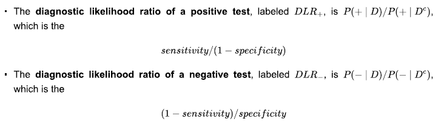

qownnotes-media-PaNiRC

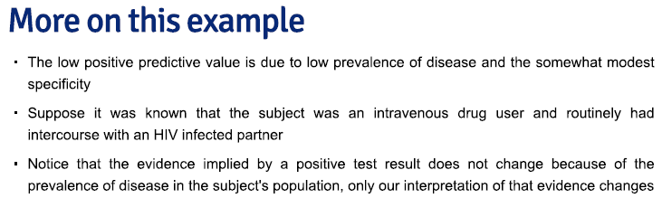

qownnotes-media-xTKrgI

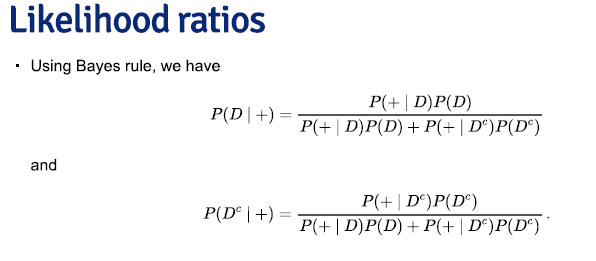

qownnotes-media-CtTfPs

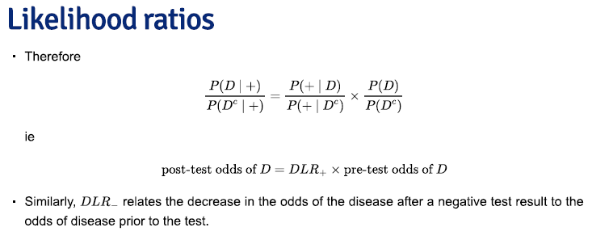

qownnotes-media-DynpEw

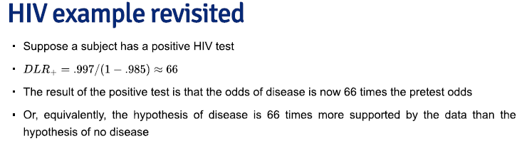

qownnotes-media-htWhsk

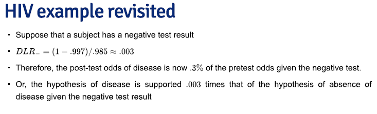

qownnotes-media-EtEyvi

## ESTUDIO DETALLADO DE LA SENSIBILIDAD Y ESPECIFICIDAD

Una vez que la prueba se ha aplicado a una población determinada, varios índices se utilizan para evaluar la prueba: - Verdadero positivos (VP): Número de casos que la prueba declara positivos y que son verdaderamente positivos. - Falsos positivos (FP): Número de casos que la prueba declara positivos y que en realidad son negativos. - Verdadero negativo (VN): Número de casos que la prueba declara negativos y que son realmente negativos. - Falsos negativos (FN): Número de casos que la prueba declara negativos y que en realidad son positivos. - N = TP + FP + FN + TN

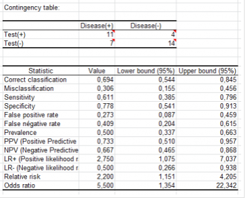

qownnotes-media-HqjvcR

- Sensibilidad (equivalente a la tasa de positivos verdaderos): Proporción de casos positivos que están bien detectadas por la prueba. La definición matemática es: Sensibilidad = VP / (VP + FN).
- Especificidad (también llamada Tasa de verdaderos negativos): proporción de casos negativos que son bien detectadas por la prueba. La definición matemática es: Especificidad = VN / (VN + FP).
- Tasa de falsos positivos (FPR): Proporción de casos negativos que la prueba detecta como positivos.
- Falso Negativo Precio (FNR): Proporción de casos positivos que la prueba detecta como negativo. - Prevalencia: la frecuencia relativa de los acontecimiento de inter?s en la muestra total (VP + FN) / N.
- Valor Predictivo Positivo (VPP): Proporción de casos verdaderamente positivos entre los casos positivos detectados por la prueba. Tenemos PPV = TP / (TP + FP), o PPV = Sensibilidad x Prevalencia / [(Sensibilidad x Prevalencia + (1-Especificidad) (1-Prevalencia)]. Es un valor fundamental que depende de la prevalencia, un índice que es independiente de la calidad de la prueba.
- Valor predictivo negativo (VPN): Proporción de casos verdaderamente negativos entre los casos negativos detectados por la prueba. Tenemos VPN = VN / (VN + FN), o VPP = Especificidad x (1 - Prevalencia) / [(Especificidad (1-Prevalencia) + (1-sensibilidad) x Prevalencia] . Este ?ndice depende tambi?n de la prevalencia que se independiente de la calidad de la prueba.
- Razón de verosimilitud positiva (LR +): Esta relación indica a qué punto una persona tiene más posibilidades de ser positivo en la realidad cuando la prueba es que está diciendo es positivo. Tenemos LR + = sensibilidad / (1-especificidad). La RP + es un valor positivo o nulo.
- Razón de verosimilitud Negativa (LR-): Esta relación indica a qué punto una persona tiene más posibilidades de ser negativo, en realidad, cuando la prueba es que está diciendo es positivo. Tenemos LR-= (1-sensibilidad) / (especificidad). El LR-es un valor positivo o nulo.
- Odds ratio: El odds ratio indica la cantidad de un individuo es más probable que sea positivo si el resultado es positivo, en comparación con los casos en que la prueba es negativa. Por ejemplo, un odds ratio de 2 significa que la probabilidad de que el caso positivo se produce es dos veces superior si la prueba es positiva que si es negativo. El odds ratio es un valor positivo o nulo. Tenemos Odds ratio = VPxVN / (FPxFN).
- El riesgo relativo: El riesgo relativo es un ratio que mide mejor la prueba se comporta cuando se trata de un informe positivo que cuando es negativo. Por ejemplo, un riesgo relativo de 2 significa que la prueba es dos veces más potente cuando es positiva que cuando es negativo. Un valor cercano a 1 corresponde a un caso de independencia entre las filas y columnas, y una prueba de que funciona tan bien cuando es positiva que cuando es negativo. El riesgo relativo es un valor nulo o un valor positivo dado por: riesgo relativo = VP / (VP + FP) / (FN / (FN + VN)).